# p8105_hw3_sz3214

Shizhe Zhang

2024-10-08

# Problem 1

**load data**

```r
library(p8105.datasets)
data("ny_noaa")
```

**Overall**

```r
str(ny_noaa)
```

```
## tibble [2,595,176 × 7] (S3: tbl_df/tbl/data.frame)
##  $ id  : chr [1:2595176] "US1NYAB0001" "US1NYAB0001" "US1NYAB0001" "US1NYAB0001" ...
##  $ date: Date[1:2595176], format: "2007-11-01" "2007-11-02" ...
##  $ prcp: int [1:2595176] NA NA NA NA NA NA NA NA NA NA ...
##  $ snow: int [1:2595176] NA NA NA NA NA NA NA NA NA NA ...
##  $ snwd: int [1:2595176] NA NA NA NA NA NA NA NA NA NA ...
##  $ tmax: chr [1:2595176] NA NA NA NA ...
##  $ tmin: chr [1:2595176] NA NA NA NA ...
##  - attr(*, "spec")=
##   .. cols(
##   ..   id = col_character(),
##   ..   date = col_date(format = ""),
##   ..   prcp = col_integer(),
##   ..   snow = col_integer(),
##   ..   snwd = col_integer(),
##   ..   tmax = col_character(),
##   ..   tmin = col_character()
##   .. )
```

```r
colMeans(is.na(ny_noaa)) * 100
```

```
##       id     date     prcp     snow     snwd     tmax     tmin
##  0.00000  0.00000  5.61958 14.68960 22.80331 43.71025 43.71264
```

The dataset consists of 2,595,176 rows and 7 columns. Each row represents a daily weather observation, and the key variables include:

`id`: A character variable identifying the weather station. `date`: A date variable representing the date of the observation. `prcp`: An integer variable indicating precipitation. `snow`: An integer variable for snowfall measurements. `snwd`: An integer variable for snow depth. `tmax`: A character variable representing the maximum temperature for the day. `tmin`: A character variable representing the minimum temperature.

Several key variables contain many NA values:

`prcp`: 5.62% missing value. `snow`: 14.69% missing value. `snwd`: 22.80% missing value. `tmax`: 43.71% missing value. `tmin`: 43.71% missing value.

**data cleaning**

```r
ny_noaa = ny_noaa |>
  janitor::clean_names() |>
  mutate(year = as.numeric(format(date, "%Y")),
         month = as.numeric(format(date, "%m")),
         day = as.numeric(format(date, "%d")),
         tmax = as.integer(tmax) / 10,
         tmin = as.integer(tmin) / 10,
         prcp = prcp / 10)

ny_noaa |>
  group_by(snow) |>
  summarise(count = n()) |>
  arrange(desc(count)) |>
  head(n=5)
```

```
## # A tibble: 5 × 2
##    snow   count
##   <int>   <int>
## 1     0 2008508
## 2    NA  381221
## 3    25   31022
## 4    13   23095
## 5    51   18274
```

The most commonly observed value for snowfall is 0.

**plot 1**

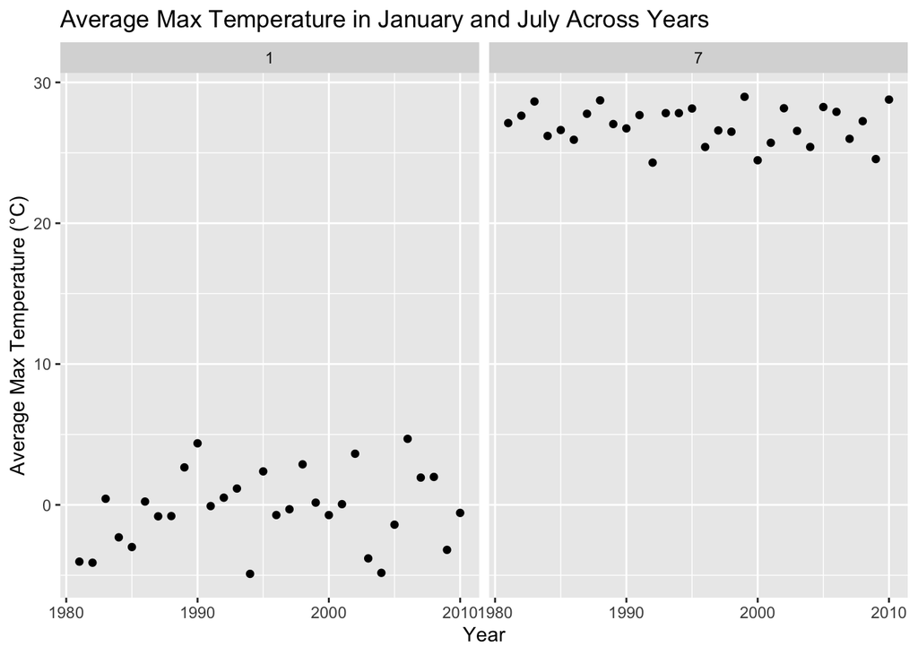

```r
ny_noaa |>
  filter(month == '1' | month == '7') |>
  group_by(year, month) |>
  summarise(avg_tmax = mean(tmax, na.rm = TRUE), .groups = "drop") |>
  ungroup() |>
  ggplot(aes(x = year, y = avg_tmax)) +
  geom_point() +
  facet_wrap(~month) +
  labs(
    title = "Average Max Temperature in January and July Across Years",
    x = "Year", y = "Average Max Temperature (°C)"
  )
```

There is a gradual increase around 0°C in temperatures over time in Jan. In July, the temperatures are around 25-30°C across all years and didn’t show obviously trend. In the January, there are a few data points slightly above or below 0°C, which could be outliers.

**plot 2**

[figure not shown]

```r
tmax_tmin = ny_noaa |>
  filter(!is.na(tmax) & !is.na(tmin)) |>
  ggplot(aes(x=tmin, y=tmax)) +
  geom_hex(bins = 30) +
  labs(title = "Hexbin Plot of Tmax vs Tmin", x = "Tmin (°C)", y = "Tmax (°C)")

snow_dist = ny_noaa |>
  filter(snow > 0 & snow < 100) |>
  ggplot(aes(x=year, y=snow)) +
  geom_violin() +
  labs(title = "Snowfall Distribution (0 < Snowfall < 100) by Year", x = "Snowfall (mm)", y = "Year")

tmax_tmin + snow_dist
```

# Problem 2

**data cleaning**

```r
accel = read.csv("nhanes_accel.csv") |>
  janitor::clean_names()

covar = read.csv("nhanes_covar.csv", skip = 4) |>
  janitor::clean_names() |>
  filter(age >= 21, !is.na(sex), !is.na(age), !is.na(bmi), !is.na(education)) |>
  mutate(
    sex = factor(sex, levels = c(1, 2), labels = c("Male", "Female")),
    education = factor(education,
                          levels = c(1, 2, 3),
                          labels = c("Less than high school",
                                     "High school equivalent",
                                     "More than high school"))
  )

mims = inner_join(accel, covar, by = "seqn")
```

**table and plot**

```r
mims |>
  group_by(sex, education) |>
  summarize(count = n()) |>
  pivot_wider(
    names_from = sex,
    values_from = count
  ) |>
  knitr::kable()
```

[output not shown]

| education | Male | Female |
| --- | --- | --- |
| Less than high school | 27 | 28 |
| High school equivalent | 35 | 23 |
| More than high school | 56 | 59 |

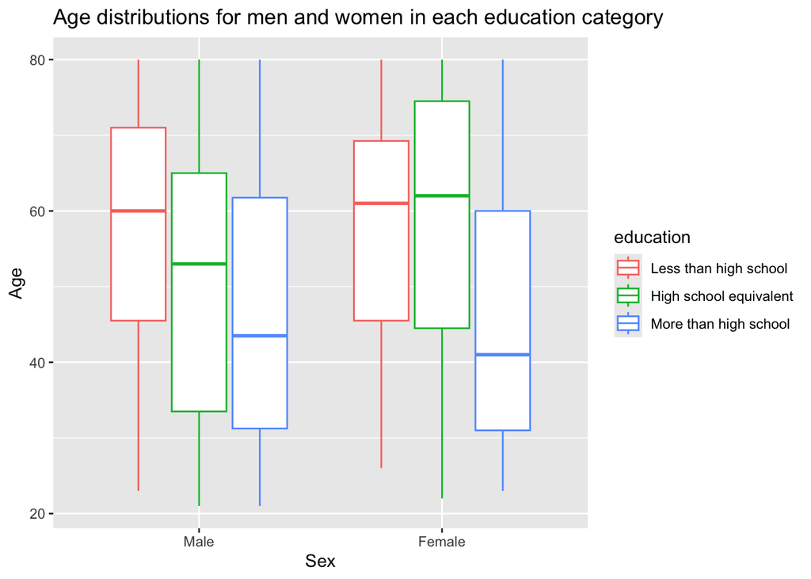

```r
mims |>
  group_by(sex, education) |>
  ggplot(aes(x = sex, y = age, color = education)) +
  geom_boxplot() +
  labs(
    title = "Age distributions for men and women in each education category",
    x = "Sex", y = "Age"
  )
```

**activity vs age**

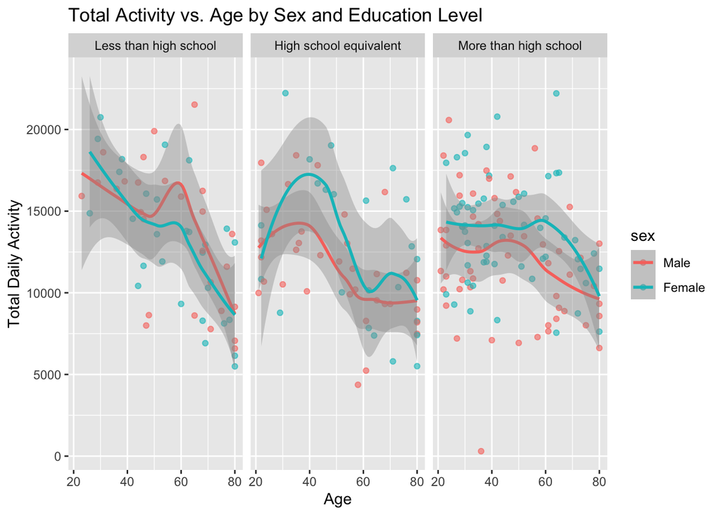

```r
mims |>
  rowwise() |>
  mutate(activity = sum(c_across(starts_with("min")), na.rm = TRUE)) |>
  ungroup() |>
  group_by(sex, education) |>
  ggplot(aes(x = age, y = activity, color = sex)) +
  geom_point(alpha = 0.6) +
  geom_smooth(method = "loess") +
  facet_wrap(~education) +
  labs(
    title = "Total Activity vs. Age by Sex and Education Level",
    x = "Age", y = "Total Daily Activity"
  )
```

Higher education levels are associated with more consistent activity patterns across the lifespan, while lower education levels show more variability and a steeper decline in activity, especially for women. Gender differences are more pronounced in the lower education groups, with women showing higher activity at younger ages but a sharper decline as they age.

**24-Hour activity courses**

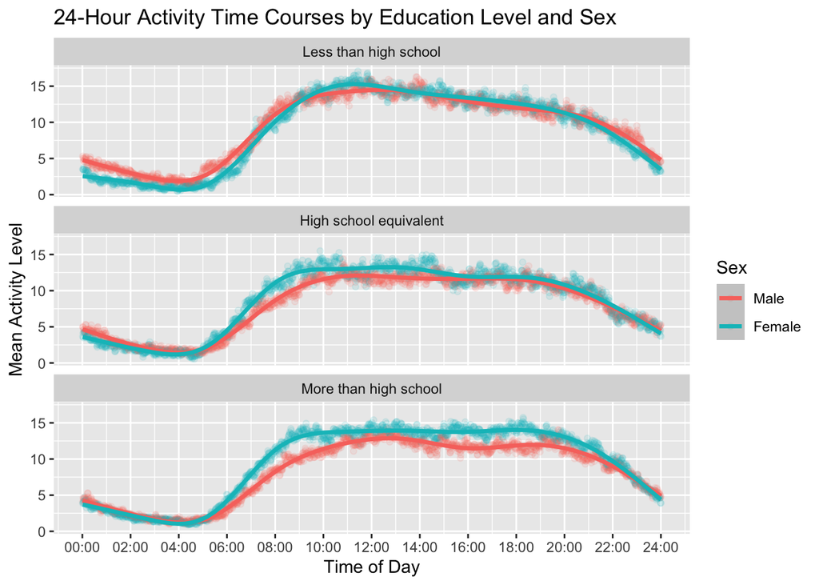

```r
mims |>
  pivot_longer(cols = starts_with("min"),
               names_to = "minute",
               names_prefix = "min",
               values_to = "activity") |>
  mutate(minute = as.numeric(minute))  |>
  group_by(minute, sex, education) |>
  summarize(mean_activity = mean(activity, na.rm = TRUE)) |>
  ggplot(aes(x = minute, y = mean_activity, color = sex)) +
  geom_point(alpha = 0.1) +
  geom_smooth(size = 1.2) +
  facet_wrap(~education, nrow = 3) +
  scale_x_continuous(breaks = seq(0, 1440, by = 120),
                     labels = function(x) sprintf("%02d:00", x / 60)) +
  labs(title = "24-Hour Activity Time Courses by Education Level and Sex",
       x = "Time of Day",
       y = "Mean Activity Level",
       color = "Sex")
```

While there are slight variations in the timing and magnitude of activity peaks, the overall daily activity pattern remains similar across all three education levels. Individuals have lower activity levels during the early morning and late night, with peaks in the late morning and early afternoon.

# Problem 3

**data cleaning**

```r
bike201 <- read.csv("citibike/Jan 2020 Citi.csv") |>
  janitor::clean_names() |>
  mutate(year = 2020, month = "Jan")
bike207 <- read.csv("citibike/July 2020 Citi.csv") |>
  janitor::clean_names() |>
  mutate(year = 2020, month = "July")
bike241 <- read.csv("citibike/Jan 2024 Citi.csv") |>
  janitor::clean_names() |>
  mutate(year = 2024, month = "Jan")
bike247 <- read.csv("citibike/July 2024 Citi.csv") |>
  janitor::clean_names() |>
  mutate(year = 2024, month = "July")

citibike = bind_rows(bike201, bike207, bike241, bike247) |>
  mutate(
    weekdays = factor(weekdays,
                      levels =c("Monday", "Tuesday", "Wednesday", "Thursday",
                                "Friday", "Saturday", "Sunday")),
    month = factor(month),
    year = factor(year),
   rideable_type = factor(rideable_type)
  )

str(citibike)
```

```
## 'data.frame':    99485 obs. of  9 variables:
##  $ ride_id           : chr  "4BE06CB33B037044" "26886E034974493B" "24DC56060EBE6260" "EEDC1053582D02E5" ...
##  $ rideable_type     : Factor w/ 2 levels "classic_bike",..: 1 1 1 1 1 1 1 1 1 1 ...
##  $ weekdays          : Factor w/ 7 levels "Monday","Tuesday",..: 2 3 5 7 5 7 7 7 4 2 ...
##  $ duration          : num  15.33 5.31 9.69 7 2.85 ...
##  $ start_station_name: chr  "Columbus Ave & W 95 St" "2 Ave & E 96 St" "Columbia St & Rivington St" "W 84 St & Columbus Ave" ...
##  $ end_station_name  : chr  "E 53 St & Madison Ave" "1 Ave & E 110 St" "Grand St & Elizabeth St" "Columbus Ave & W 72 St" ...
##  $ member_casual     : chr  "member" "member" "member" "member" ...
##  $ year              : Factor w/ 2 levels "2020","2024": 1 1 1 1 1 1 1 1 1 1 ...
##  $ month             : Factor w/ 2 levels "Jan","July": 1 1 1 1 1 1 1 1 1 1 ...
```

The final dataset contains 99485 observations with 9 variables including: `ride_id`, `rideable_type`, `weekdays`, `duration`, `start_station_name`, `end_station_name`, `member_casual`, `year`, `month`.

**table 1**

```r
citibike |>
  group_by(year, month, member_casual) |>
  summarize(number = n()) |>
  pivot_wider(
    names_from = member_casual,
    values_from = number) |>
  knitr::kable()
```

| year | month | casual | member |
| --- | --- | --- | --- |
| 2020 | Jan | 984 | 11436 |
| 2020 | July | 5637 | 15411 |
| 2024 | Jan | 2108 | 16753 |
| 2024 | July | 10894 | 36262 |

From 2020 to 2024, there is notable growth in total rides, especially in July 2024, where ridership has surged. This suggests increased popularity and perhaps expanded infrastructure or public interest in bike-sharing.

**table 2**

```r
citibike |>
  filter(year == 2024, month == "July") |>
  group_by(start_station_name) |>
  summarize(total_ride = n()) |>
  arrange(desc(total_ride)) |>
  slice_max(total_ride, n = 5) |>
  knitr::kable(caption = "Top 5 Most Popular Starting Stations for July 2024")
```

Top 5 Most Popular Starting Stations for July 2024

| start_station_name | total_ride |
| --- | --- |
| Pier 61 at Chelsea Piers | 163 |
| University Pl & E 14 St | 155 |
| W 21 St & 6 Ave | 152 |
| West St & Chambers St | 150 |
| W 31 St & 7 Ave | 146 |

**plot 1**

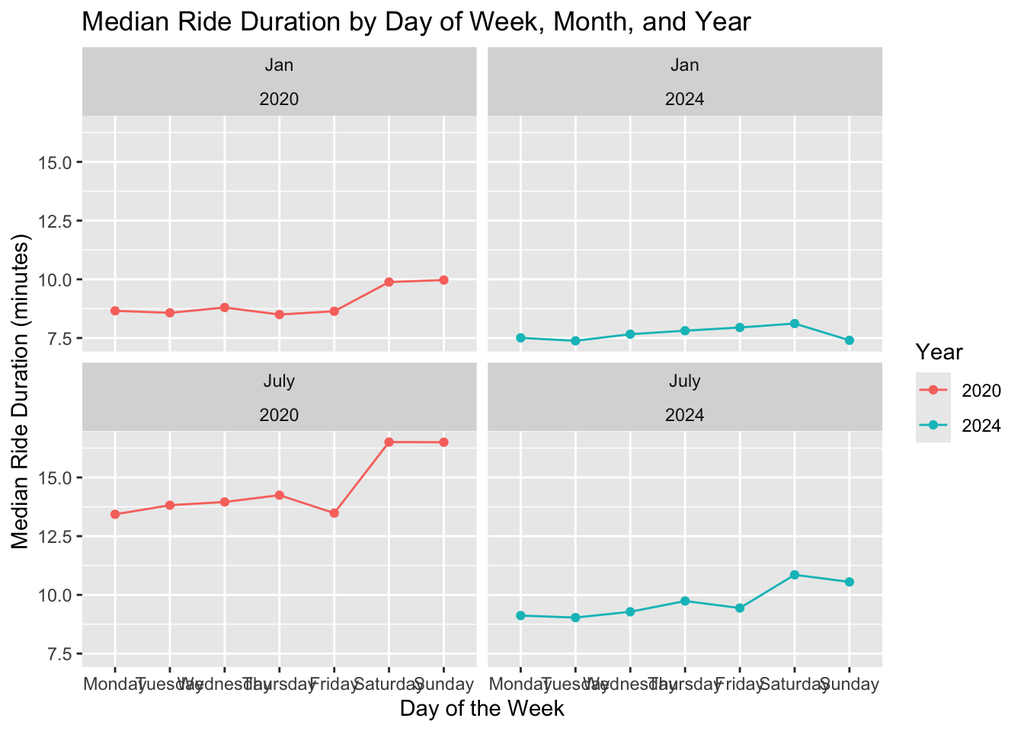

```r
citibike |>
  group_by(year, month, weekdays) |>
  summarize(median_duration = median(duration)) |>
  ggplot(aes(x = weekdays, y = median_duration, color = factor(year))) +
  geom_point(aes(group = year)) +
  geom_line(aes(group = year)) +
  facet_wrap(~ month + year, ncol = 2, nrow = 2) +
  labs(title = "Median Ride Duration by Day of Week, Month, and Year",
       x = "Day of the Week",
       y = "Median Ride Duration (minutes)",
       color = "Year")
```

The colder month of January has generally shorter ride durations compared to July. In both 2020 and 2024, weekends tend to see longer rides, particularly in July.

**plot 2**

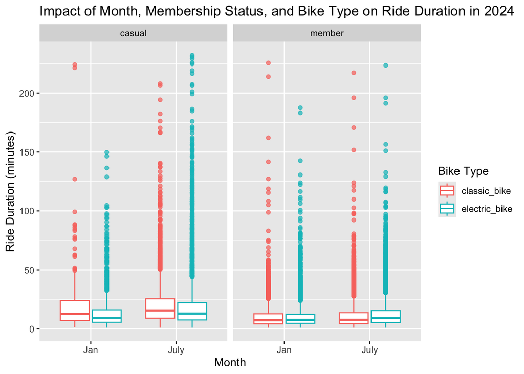

```r
citibike |>
  filter(year == 2024) |>
  ggplot(aes(x = month, y = duration, color = rideable_type)) +
  geom_boxplot(outlier.alpha = 0.7) +
  facet_wrap(~ member_casual) +
  labs(title = "Impact of Month, Membership Status, and Bike Type on Ride Duration in 2024",
       x = "Month",
       y = "Ride Duration (minutes)",
       color = "Bike Type")
```